# NMF Final (Full time period))

## LS-NMF + nndsvd seed

```r
# Run nmf with 4:10 components and nndsvd seed
# start_time_lsnmf_nndsvd <- Sys.time()
#
# lsnmf_nndsvd_less_o3 <- nmf(
#   normalized_matrix_less_o3,
#   rank = components,
#   nrun = 1, # since using nndsvd
#   method = "ls-nmf",
#   weight = weight_matrix,
#   seed = 'nndsvd'
# )
#
# end_time_lsnmf_nndsvd <- Sys.time()
# end_time_lsnmf_nndsvd-start_time_lsnmf_nndsvd
# 1.37 minutes to run the above
# #
# saveRDS(lsnmf_nndsvd_less_o3,
#         'lsnmf_nndsvd_less_o3.rds')

lsnmf_nndsvd_less_o3 <- readRDS('lsnmf_nndsvd_less_o3.rds')
```

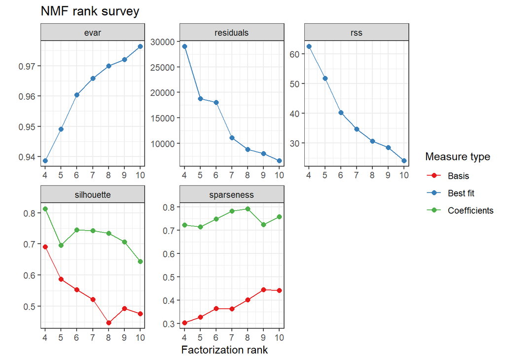

```r
# plots the NMF rank survey
plot(lsnmf_nndsvd_less_o3)
```

### Look at 5 factors:

```r
output <- lsnmf_nndsvd_less_o3$fit$`5`
W <- basis(output)
H <- coef(output)
```

#### Source Contribution plots

- Source Contribution plots

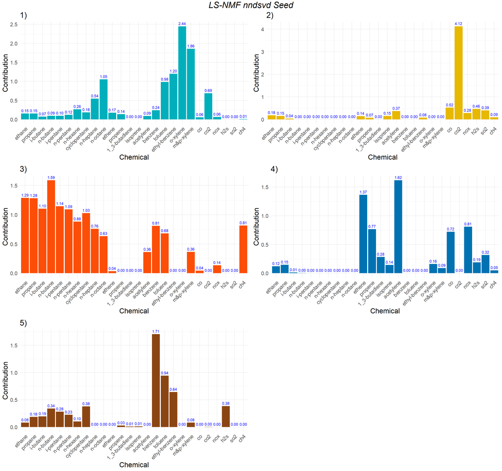

```r
# Convert H to a data frame for ggplot
H_df_5c_less_o3 <- as.data.frame(H)
# Add a column for chemicals
H_df_5c_less_o3$Component <- rownames(H_df_5c_less_o3)

# Reshape data to long format
H_long_5c_less_o3 <- pivot_longer(H_df_5c_less_o3, cols = -Component,
                                  names_to = "Chemical", values_to = "Contribution")

# Plot
nmfplt_1_lsnmf_nndsvd_less_o3_5c <- get_component_plot(H_long_5c_less_o3,
                                           '1', '1)')
nmfplt_2_lsnmf_nndsvd_less_o3_5c <- get_component_plot(H_long_5c_less_o3,
                                           '2', '2)')
nmfplt_3_lsnmf_nndsvd_less_o3_5c <- get_component_plot(H_long_5c_less_o3,
                                           '3', '3)')
nmfplt_4_lsnmf_nndsvd_less_o3_5c <- get_component_plot(H_long_5c_less_o3,
                                           '4', '4)')
nmfplt_5_lsnmf_nndsvd_less_o3_5c <- get_component_plot(H_long_5c_less_o3,
                                           '5', '5)')
```

#### Fingerprint plot

- Fingerprint plots

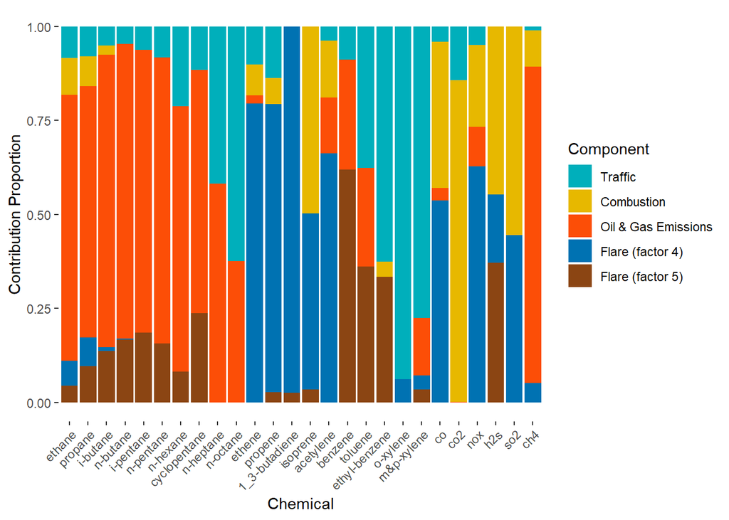

```r
fingerprint <- get_fingerprint_plot(H_df_5c_less_o3, c(
      'Traffic',
      'Combustion',
      'Oil & Gas Emissions',
      'Flare (factor 4)',
      'Flare (factor 5)'
    ))
fingerprint
```

```r
#ggsave("fingerprint.png", c)
```

#### Wind plot

- Wind plots

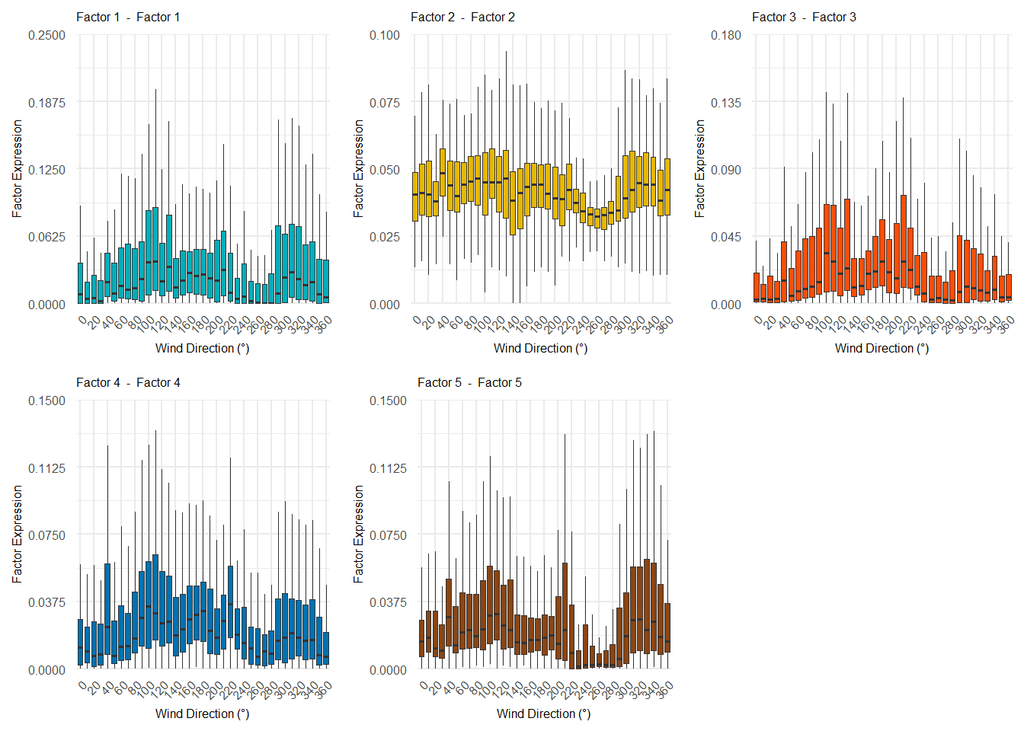

```r
wind_plot <- get_wind_plots(W, y_axis_upper = c(0.25, 0.1, 0.18, 0.15, 0.15))
grid.arrange(grobs = wind_plot, ncol = 3)
```

## Comparing random seed vs nndsvd for ls-nmf

Residuals is defined as sum(((X - fitted(object)) * weight)^2)/2

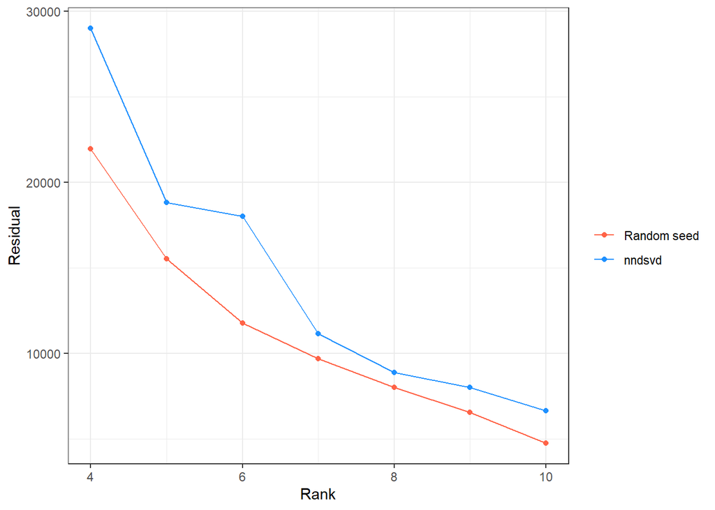

```r
tibble(component = components,
       random_residual = lsnmf_random_less_o3$measures$residuals,
       nndsvd_residual = lsnmf_nndsvd_less_o3$measures$residuals) %>%
  ggplot() +
  geom_line(aes(x = component, y =random_residual, color = 'Random seed')) +
  geom_point(aes(x = component, y =random_residual, color = 'Random seed')) +
  geom_line(aes(x = component, y = nndsvd_residual, color = 'nndsvd')) +
  geom_point(aes(x = component, y = nndsvd_residual, color = 'nndsvd')) +
  scale_colour_manual("",
                    breaks = c("Random seed", "nndsvd"),
                    values = c("tomato1", "dodgerblue")) +
  labs(x = 'Rank', y = 'Residual', 'WRSS') +
  theme_bw()
```

## KL + Random seed

```r
# start_time_kl_random <- Sys.time()
#
# kl_random_less_o3 <- nmf(
#   normalized_matrix_less_o3,
#   rank = components,
#   nrun = 30,
#   method = "KL",
#   seed = 123456
# )
#
# end_time_kl_random <- Sys.time()
# end_time_kl_random-start_time_kl_random
# 14.84 minutes to run the above

# saveRDS(kl_random_less_o3, 'kl_random_less_o3.rds')

kl_random_less_o3 <- readRDS('kl_random_less_o3.rds')
```

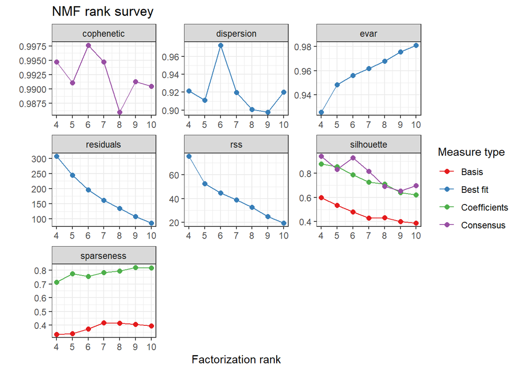

```r
# plots the NMF rank survey
plot(kl_random_less_o3)
```

### Look at 5 factors:

```r
output <- kl_random_less_o3$fit$`5`
W <- basis(output)
H <- coef(output)
```

#### Source Contribution plots

- Source Contribution plots

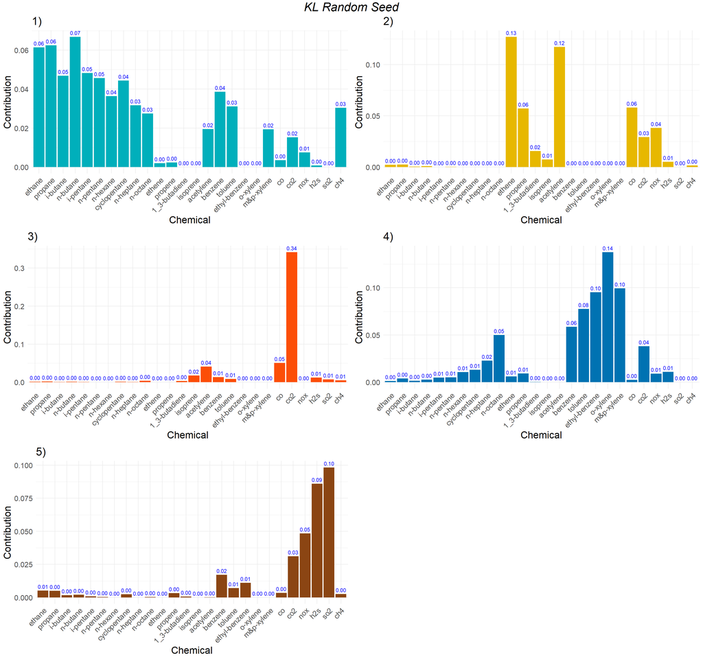

```r
# Convert H to a data frame for ggplot
H_df_5c_less_o3 <- as.data.frame(H)
# Add a column for chemicals
H_df_5c_less_o3$Component <- rownames(H_df_5c_less_o3)

# Reshape data to long format
H_long_5c_less_o3 <- pivot_longer(H_df_5c_less_o3, cols = -Component,
                                  names_to = "Chemical", values_to = "Contribution")

# Plot
nmfplt_1_kl_random_less_o3_5c <- get_component_plot(H_long_5c_less_o3,
                                           '1', '1)')
nmfplt_2_kl_random_less_o3_5c <- get_component_plot(H_long_5c_less_o3,
                                           '2', '2)')
nmfplt_3_kl_random_less_o3_5c <- get_component_plot(H_long_5c_less_o3,
                                           '3', '3)')
nmfplt_4_kl_random_less_o3_5c <- get_component_plot(H_long_5c_less_o3,
                                           '4', '4)')
nmfplt_5_kl_random_less_o3_5c <- get_component_plot(H_long_5c_less_o3,
                                           '5', '5)')
```

#### Fingerprint plot

- Fingerprint plots

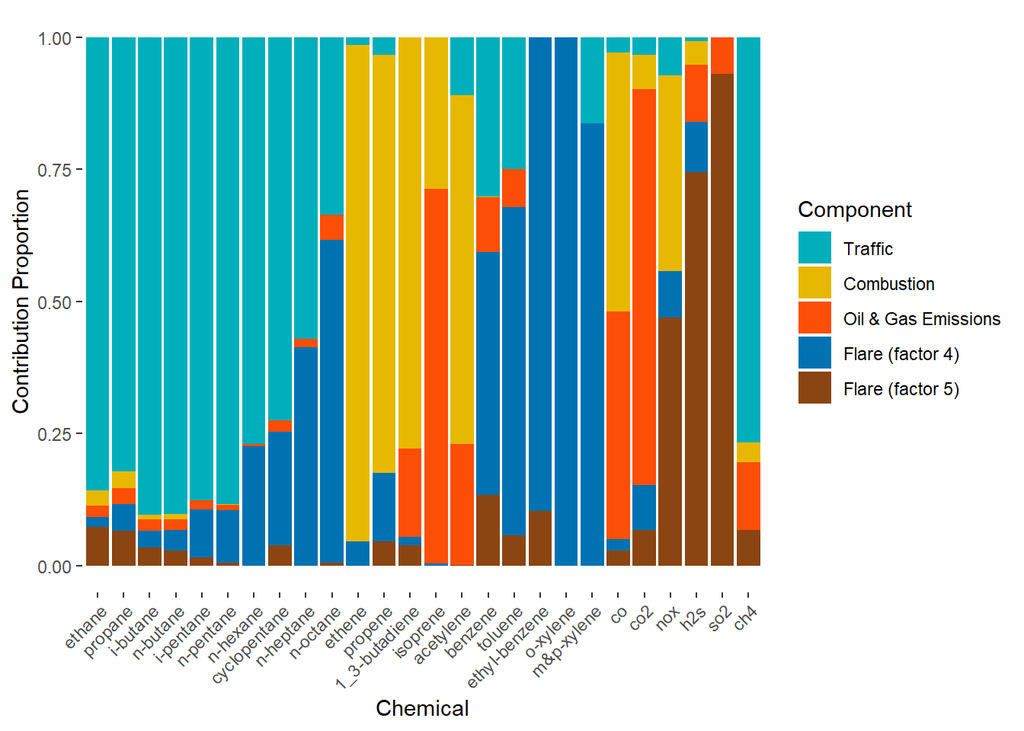

```r
fingerprint <- get_fingerprint_plot(H_df_5c_less_o3, c(
      'Traffic',
      'Combustion',
      'Oil & Gas Emissions',
      'Flare (factor 4)',
      'Flare (factor 5)'
    ))
fingerprint
```

```r
#ggsave("fingerprint.png", c)
```

#### Wind plot

- Wind plots

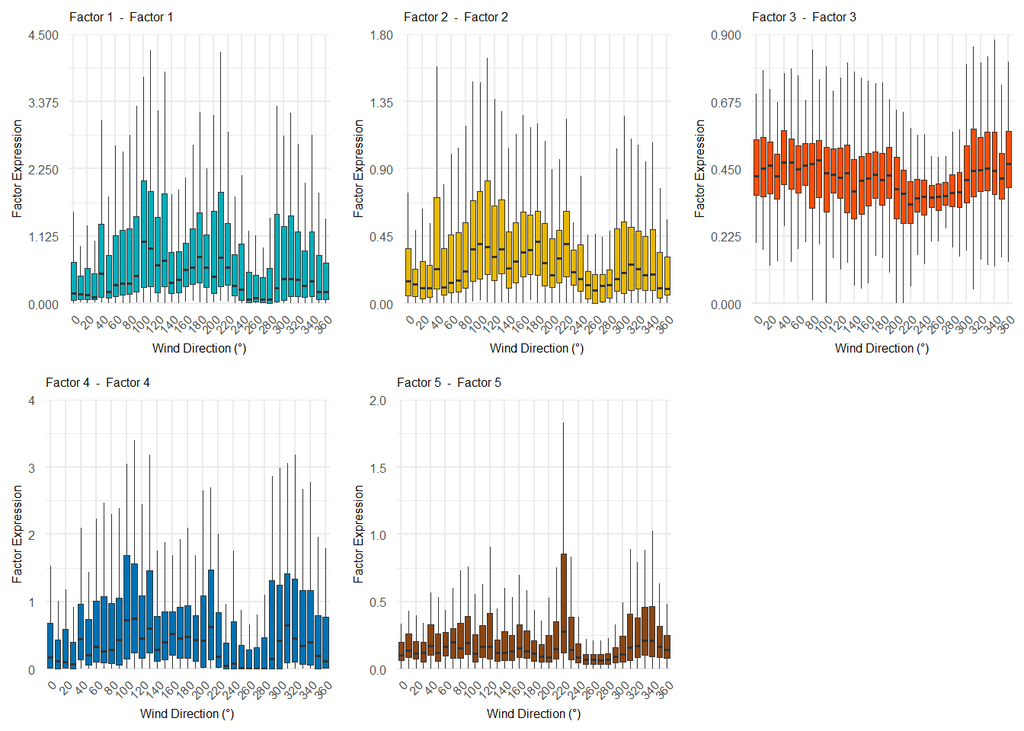

```r
wind_plot <- get_wind_plots(W, y_axis_upper = c(4.5, 1.8, 0.9, 4, 2))
grid.arrange(grobs = wind_plot, ncol = 3)
```

## KL + nndsvd

```r
errors <- numeric(length(components) - 4)

# Loop over the number of components
# for (n in components) {
#   nmf_result <- nmf(normalized_matrix_less_o3, rank = n, method = "KL", seed='nndsvd')
#   reconstruction <- basis(nmf_result) %*% coef(nmf_result)
#   error <- norm(normalized_matrix_less_o3 - reconstruction, type = "F")^2 # RSS
#   errors[n-3] <- error
#   print(paste0('Completed ', n - 3, ' out of 7'))
# }
#
# saveRDS(errors, 'errors_KL_nndsvd_less_o3.rds')
#
# errors <- readRDS('errors_KL_nndsvd_less_o3.rds')

# start_time_kl_nndsvd <- Sys.time()
# #
# kl_nndsvd_less_o3 <- nmf(
#   normalized_matrix_less_o3,
#   rank = components,
#   nrun = 1,
#   method = "KL",
#   seed = 'nndsvd'
# )
#
# end_time_kl_nndsvd <- Sys.time()
# end_time_kl_nndsvd-start_time_kl_nndsvd
# # 1 minute to run the above
#
# saveRDS(kl_nndsvd_less_o3, 'kl_nndsvd_less_o3.rds')

kl_nndsvd_less_o3 <- readRDS('kl_nndsvd_less_o3.rds')
```

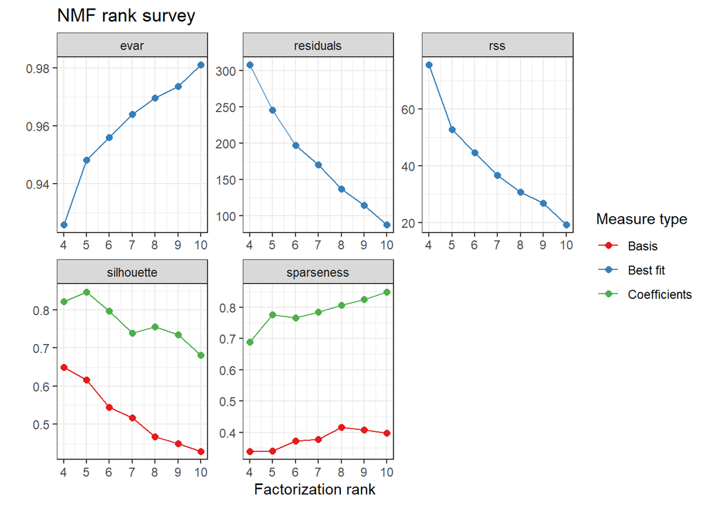

```r
# plots the NMF rank survey
plot(kl_nndsvd_less_o3)
```

### Look at 5 factors:

```r
output <- kl_nndsvd_less_o3$fit$`5`
W <- basis(output)
H <- coef(output)
```

#### Source Contribution plots

- Source Contribution plots

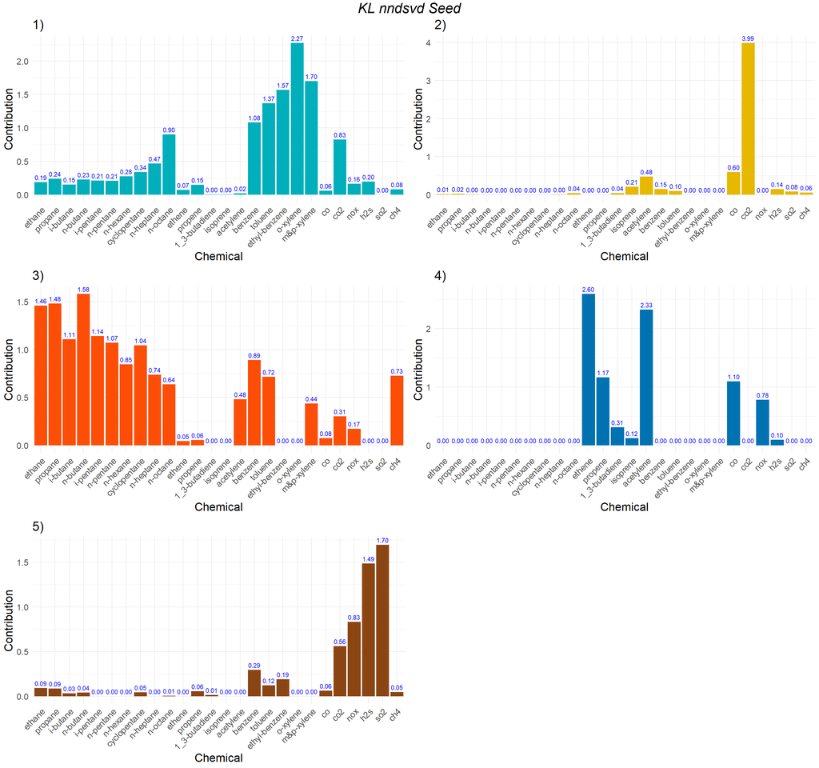

```r
# Convert H to a data frame for ggplot
H_df_5c_less_o3 <- as.data.frame(H)
# Add a column for chemicals
H_df_5c_less_o3$Component <- rownames(H_df_5c_less_o3)

# Reshape data to long format
H_long_5c_less_o3 <- pivot_longer(H_df_5c_less_o3, cols = -Component,
                                  names_to = "Chemical", values_to = "Contribution")

# Plot
nmfplt_1_kl_nndsvd_less_o3_5c <- get_component_plot(H_long_5c_less_o3,
                                           '1', '1)')
nmfplt_2_kl_nndsvd_less_o3_5c <- get_component_plot(H_long_5c_less_o3,
                                           '2', '2)')
nmfplt_3_kl_nndsvd_less_o3_5c <- get_component_plot(H_long_5c_less_o3,
                                           '3', '3)')
nmfplt_4_kl_nndsvd_less_o3_5c <- get_component_plot(H_long_5c_less_o3,
                                           '4', '4)')
nmfplt_5_kl_nndsvd_less_o3_5c <- get_component_plot(H_long_5c_less_o3,
                                           '5', '5)')
```

#### Fingerprint plot

- Fingerprint plots

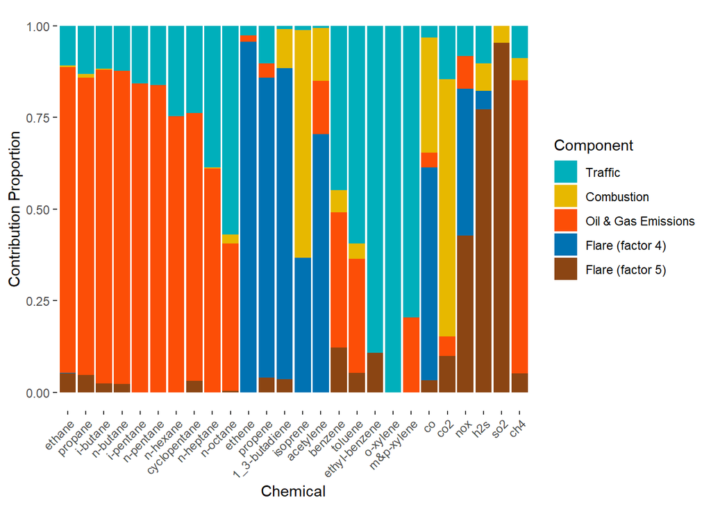

```r
fingerprint <- get_fingerprint_plot(H_df_5c_less_o3, c(
      'Traffic',
      'Combustion',
      'Oil & Gas Emissions',
      'Flare (factor 4)',
      'Flare (factor 5)'
    ))
fingerprint
```

```r
#ggsave("fingerprint.png", c)
```

#### Wind plot

- Wind plots

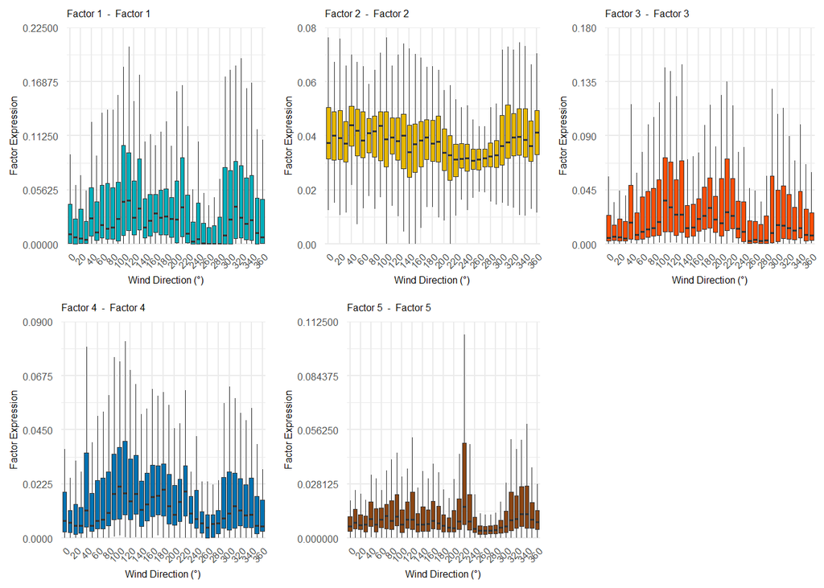

```r
wind_plot <- get_wind_plots(W, y_axis_upper = c(0.225, 0.08, 0.18, 0.09, 0.1125))
grid.arrange(grobs = wind_plot, ncol = 3)
```

## Comparing all four methods

Using RSS, WRSS, and KL

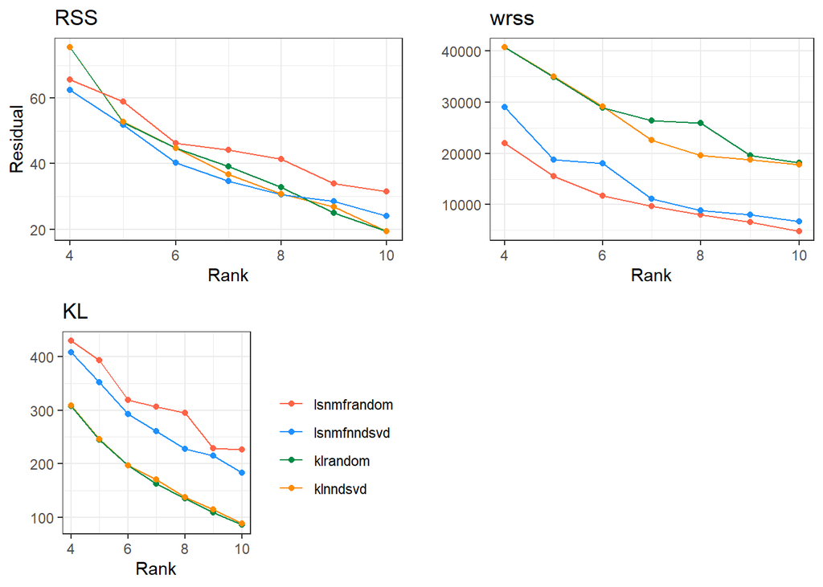

```r
get_residual <- function(component, seed, method, objective) {
  fitted <- fitted(get(paste(method, seed, 'less_o3', sep = '_'))$fit[[component-3]])
  if (objective == 'wrss') {
    return(sum(((normalized_matrix_less_o3 - fitted) * weight_matrix)^2)/2)
  } else if (objective == 'kl') {
    log_term <- normalized_matrix_less_o3/fitted
    log_term[log_term<.Machine$double.eps] <- .Machine$double.eps
    return(sum(normalized_matrix_less_o3 * log(log_term) + fitted - normalized_matrix_less_o3))
  } else if (objective == 'rss') {
    return(norm(normalized_matrix_less_o3 - fitted, type = 'F')^2)
  }
}

df_plot <- expand_grid(
  component = components,
  seed = c('random', 'nndsvd'),
  method = c('lsnmf', 'kl'),
  objective = c('rss', 'wrss', 'kl')
) %>%
  rowwise() %>%
  mutate(residual = get_residual(component, seed, method, objective)) %>%
  ungroup() %>%
  mutate(model = paste0(method, seed))

RSS_plot <- df_plot %>%
  filter(objective=='rss') %>%
  ggplot() +
  geom_line(aes(x = component, y = residual, group = model, color = model)) +
  geom_point(aes(x = component, y = residual, group = model, color = model)) +
  scale_colour_manual("",
                    breaks = c("lsnmfrandom", "lsnmfnndsvd",
                               "klrandom", "klnndsvd"),
                    values = c("tomato1", "dodgerblue",
                               "springgreen4", "darkorange")) +
  labs(x = 'Rank', y = 'Residual', title = 'RSS') +
  theme_bw() +
  theme(legend.position="none")

WRSS_plot <- df_plot %>%
  filter(objective=='wrss') %>%
  ggplot() +
  geom_line(aes(x = component, y = residual, group = model, color = model)) +
  geom_point(aes(x = component, y = residual, group = model, color = model)) +
  scale_colour_manual("",
                  breaks = c("lsnmfrandom", "lsnmfnndsvd",
                             "klrandom", "klnndsvd"),
                  values = c("tomato1", "dodgerblue",
                             "springgreen4", "darkorange")) +
  labs(x = 'Rank', y = '', title = 'wrss') +
  theme_bw() +
  theme(legend.position="none")

KL_plot <- df_plot %>%
  filter(objective=='kl') %>%
  ggplot() +
  geom_line(aes(x = component, y = residual, group = model, color = model)) +
  geom_point(aes(x = component, y = residual, group = model, color = model)) +
  scale_colour_manual("",
                    breaks = c("lsnmfrandom", "lsnmfnndsvd",
                               "klrandom", "klnndsvd"),
                    values = c("tomato1", "dodgerblue",
                               "springgreen4", "darkorange")) +
  labs(x = 'Rank', y = '', title = 'KL') +
  theme_bw()
grid.arrange(RSS_plot, WRSS_plot, KL_plot, ncol=2)
```

## NMF with 5 source factors without ozone

- remove ozone
- use KL divergence loss with svd seed
- Extract W (basis) and H (coefs) matrices
- Calculate variance explained in all 5 factors
- Calculate variance explained by each factor

```r
nmf_result_5c_less_o3 <- kl_nndsvd_less_o3$fit$`5`

basis_matrix_5c_less_o3 <- basis(nmf_result_5c_less_o3) #W
coef_matrix_5c_less_o3 <- coef(nmf_result_5c_less_o3) #H

# get variance explained by the factors (total residuals)
reconstruct<-fitted(nmf_result_5c_less_o3)

tss <- sum((normalized_matrix_less_o3 - mean(normalized_matrix_less_o3))^2)
rss <- sum((normalized_matrix_less_o3 - reconstruct)^2)
variance_explained <- 1 - (rss / tss)
variance_explained
```

```
## [1] 0.9212864
```

```r
# get variance explained by each factor separately
# Compute variance explained by each factor
# Initialize variance explained tracker
variance_explained_factors <- numeric(5)

# Incrementally add factors and calculate variance explained
reconstruction <- matrix(0, nrow = nrow(basis_matrix_5c_less_o3), ncol = ncol(coef_matrix_5c_less_o3))

for (i in 1:5) {
  # Add the i-th factor to the reconstruction
  reconstruction <- reconstruction + (basis_matrix_5c_less_o3[, i, drop=FALSE] %*% coef_matrix_5c_less_o3[i, , drop=FALSE])

  # Compute Residual Sum of Squares (RSS)
  rss_f <- sum((normalized_matrix_less_o3 - reconstruction)^2)

  # Compute Variance Explained by adding this factor
  variance_explained_factors[i] <- 1 - (rss_f / tss)
}

# Print variance explained by each factor cumulatively
variance_explained_factors
```

```
## [1] 0.2395401 0.5113683 0.8113445 0.8921360 0.9212864
```

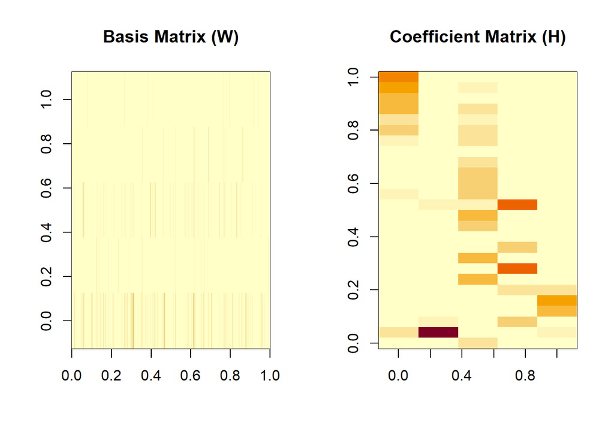

```r
par(mfrow = c(1, 2))
image(basis_matrix_5c_less_o3, main = "Basis Matrix (W)")
image(coef_matrix_5c_less_o3, main = "Coefficient Matrix (H)")
```

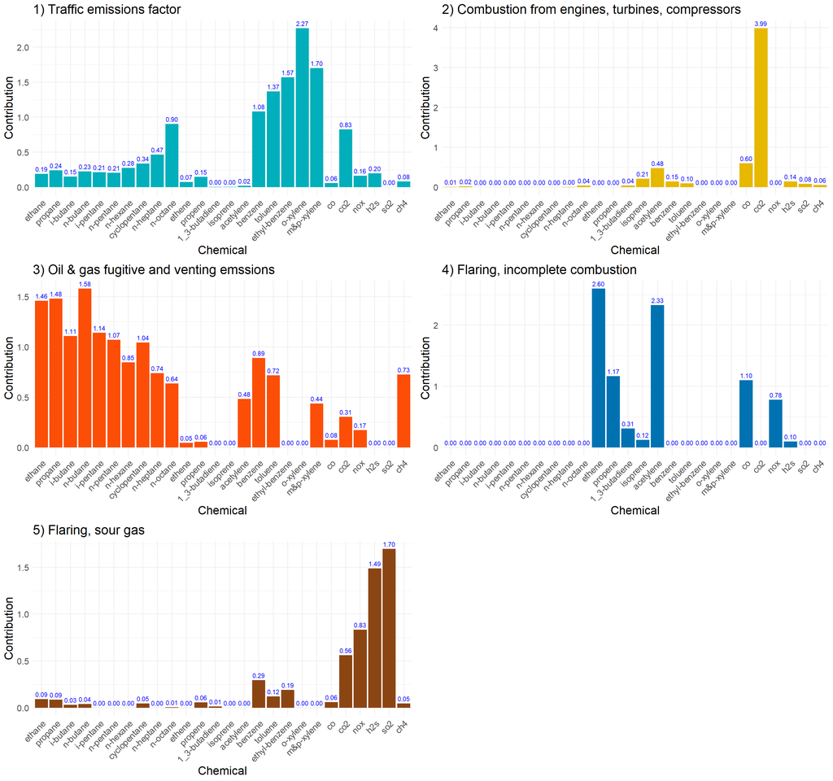

```r
# Convert H to a data frame for ggplot
H_df_5c_less_o3 <- as.data.frame(coef_matrix_5c_less_o3)
# Add a column for chemicals
H_df_5c_less_o3$Component <- rownames(H_df_5c_less_o3)

# Reshape data to long format
H_long_5c_less_o3 <- pivot_longer(H_df_5c_less_o3, cols = -Component,
                                  names_to = "Chemical", values_to = "Contribution")

# Plot
nmfplt_1_svd_5c_less_o3 <- get_component_plot(H_long_5c_less_o3,
                                           '1', '1) Traffic emissions factor')
nmfplt_2_svd_5c_less_o3 <- get_component_plot(H_long_5c_less_o3,
                                           '2', '2) Combustion from engines, turbines, compressors')
nmfplt_3_svd_5c_less_o3 <- get_component_plot(H_long_5c_less_o3,
                                           '3', '3) Oil & gas fugitive and venting emssions')
nmfplt_4_svd_5c_less_o3 <- get_component_plot(H_long_5c_less_o3,
                                           '4', '4) Flaring, incomplete combustion')
nmfplt_5_svd_5c_less_o3 <- get_component_plot(H_long_5c_less_o3,
                                           '5', '5) Flaring, sour gas')
```

## Factor analysis

- merge in factors 1-5 to dataset (hourly)

```r
# First look at how well this approximates
fitted_5c_less_o3 <- fitted(nmf_result_5c_less_o3)
sum(abs(normalized_matrix_less_o3-fitted_5c_less_o3))
```

```
## [1] 1059.63
```

```r
# NMF factorizes V = WH
# Store Basis matrix (W) and Coef Matrix (H)
saveRDS(basis_matrix_5c_less_o3, 'result_rfiles/nmf_norm_5c_less_o3_basis.rds')
saveRDS(coef_matrix_5c_less_o3, 'result_rfiles/nmf_norm_5c_less_o3_coef.rds')

# Merge basis matrix into hourly observations
basis_matrix_5c_less_o3 <- as_tibble(basis_matrix_5c_less_o3) %>%
  setNames(c('Factor1', 'Factor2', 'Factor3', 'Factor4', 'Factor5'))
normalized_hourly_data_5c_less_o3 <- hourly_nona[,c('day', 'time_utc')] %>%
  cbind(normalized_matrix_less_o3) %>%
  cbind(basis_matrix_5c_less_o3) %>%
  right_join(hourly_data %>% select(-'day'), join_by(time_utc), suffix = c('_norm', ''))

# saveRDS(normalized_hourly_data_5c_less_o3,
#  'result_rfiles/normalized_hourly_data_5c_less_o3.rds')
normalized_hourly_data_5c_less_o3 <- readRDS('result_rfiles/normalized_hourly_data_5c_less_o3.rds')
```

- make daily dataset for VNF analysis
- compute wind directions from plots

```r
# Also compute a daily dataset
normalized_daily_data_5c_less_o3 <- normalized_hourly_data_5c_less_o3 %>%
  group_by(day) %>%
  summarise(across(where(is.numeric) & !any_of('wdr_deg'), ~ mean(.x, na.rm = T)),
            wdr_deg = as.numeric(mean(circular(wdr_deg, units = "degrees"), na.rm = T))) %>%
  mutate(wdr_deg = if_else(wdr_deg < 0, wdr_deg+360, wdr_deg)) %>%
  mutate(wind_45_135 = wdr_deg >= 45 & wdr_deg < 135,
         wind_135_180 = wdr_deg >= 135 & wdr_deg < 180,
         wind_180_270 = wdr_deg >= 180 & wdr_deg < 270,
         wind_270_45 = wdr_deg >= 270 & wdr_deg < 45)

# saveRDS(normalized_daily_data_5c_less_o3,
#  'result_rfiles/normalized_daily_data_5c_less_o3.rds')

normalized_daily_data_5c_less_o3 <-
  readRDS('result_rfiles/normalized_daily_data_5c_less_o3.rds')
```

- 1. number of flares in 100km of trailer associated with NMF
- 2. weighted count based on distance to trailer

```r
# Check if relationship between # flares and flare factor (4 & 5)
# Linear model
flare_factor <- lm(n_flare_100 ~ Factor1 + Factor2 + Factor3 + Factor4 + Factor5,
                   data = normalized_daily_data_5c_less_o3)
summary(flare_factor)
```

```
##
## Call:
## lm(formula = n_flare_100 ~ Factor1 + Factor2 + Factor3 + Factor4 +
##     Factor5, data = normalized_daily_data_5c_less_o3)
##
## Residuals:
##     Min      1Q  Median      3Q     Max
## -54.638 -22.160   4.205  18.488  76.270
##
## Coefficients:
##             Estimate Std. Error t value Pr(>|t|)
## (Intercept)   52.438      7.455   7.034 1.61e-11 ***
## Factor1      -27.402    106.172  -0.258   0.7965
## Factor2     -338.560    196.573  -1.722   0.0861 .
## Factor3      286.534    151.310   1.894   0.0593 .
## Factor4     -287.536    244.717  -1.175   0.2410
## Factor5      231.978    212.510   1.092   0.2760
## ---
## Signif. codes:  0 '***' 0.001 '**' 0.01 '*' 0.05 '.' 0.1 ' ' 1
##
## Residual standard error: 27.79 on 273 degrees of freedom
##   (1 observation deleted due to missingness)
## Multiple R-squared:  0.03877,    Adjusted R-squared:  0.02117
## F-statistic: 2.202 on 5 and 273 DF,  p-value: 0.05434
```

```r
flare_factor45 <- lm(n_flare_100 ~ Factor4 + Factor5, data = normalized_daily_data_5c_less_o3)
summary(flare_factor45)
```

```
##
## Call:
## lm(formula = n_flare_100 ~ Factor4 + Factor5, data = normalized_daily_data_5c_less_o3)
##
## Residuals:
##     Min      1Q  Median      3Q     Max
## -53.409 -23.830   5.588  18.235  77.131
##
## Coefficients:
##             Estimate Std. Error t value Pr(>|t|)
## (Intercept)   40.780      3.386  12.044   <2e-16 ***
## Factor4      -48.431    150.383  -0.322   0.7477
## Factor5      360.559    206.393   1.747   0.0818 .
## ---
## Signif. codes:  0 '***' 0.001 '**' 0.01 '*' 0.05 '.' 0.1 ' ' 1
##
## Residual standard error: 28.02 on 276 degrees of freedom
##   (1 observation deleted due to missingness)
## Multiple R-squared:  0.01171,    Adjusted R-squared:  0.004548
## F-statistic: 1.635 on 2 and 276 DF,  p-value: 0.1968
```

```r
flare_factor_weighted <- lm(weighted.count ~ Factor1 + Factor2 + Factor3 + Factor4 + Factor5,
                            data = normalized_daily_data_5c_less_o3)
summary(flare_factor_weighted)
```

```
##
## Call:
## lm(formula = weighted.count ~ Factor1 + Factor2 + Factor3 + Factor4 +
##     Factor5, data = normalized_daily_data_5c_less_o3)
##
## Residuals:
##     Min      1Q  Median      3Q     Max
## -2.3295 -0.2180  0.0546  0.3809  3.9848
##
## Coefficients:
##             Estimate Std. Error t value Pr(>|t|)
## (Intercept)   2.2572     0.2278   9.907   <2e-16 ***
## Factor1       0.1244     3.2450   0.038   0.9694
## Factor2      -4.7740     6.0080  -0.795   0.4275
## Factor3       7.4339     4.6246   1.607   0.1091
## Factor4     -12.9155     7.4794  -1.727   0.0853 .
## Factor5       4.0762     6.4951   0.628   0.5308
## ---
## Signif. codes:  0 '***' 0.001 '**' 0.01 '*' 0.05 '.' 0.1 ' ' 1
##
## Residual standard error: 0.8492 on 273 degrees of freedom
##   (1 observation deleted due to missingness)
## Multiple R-squared:  0.02221,    Adjusted R-squared:  0.0043
## F-statistic:  1.24 on 5 and 273 DF,  p-value: 0.2905
```

```r
flare_factor_weighted45 <- lm(weighted.count ~ Factor4 + Factor5,
                              data = normalized_daily_data_5c_less_o3)
summary(flare_factor_weighted45)
```

```
##
## Call:
## lm(formula = weighted.count ~ Factor4 + Factor5, data = normalized_daily_data_5c_less_o3)
##
## Residuals:
##     Min      1Q  Median      3Q     Max
## -2.2558 -0.1821  0.0775  0.3622  3.9366
##
## Coefficients:
##             Estimate Std. Error t value Pr(>|t|)
## (Intercept)   2.0910     0.1029  20.315   <2e-16 ***
## Factor4      -4.0144     4.5712  -0.878    0.381
## Factor5       7.3663     6.2738   1.174    0.241
## ---
## Signif. codes:  0 '***' 0.001 '**' 0.01 '*' 0.05 '.' 0.1 ' ' 1
##
## Residual standard error: 0.8518 on 276 degrees of freedom
##   (1 observation deleted due to missingness)
## Multiple R-squared:  0.005595,   Adjusted R-squared:  -0.001611
## F-statistic: 0.7765 on 2 and 276 DF,  p-value: 0.461
```

```r
# All factors + wind speed + wind direction + factor5:sw wind.
# Wind direction from 270 to 45 is left as reference group.
flare_factor_weighted_2 <- lm(weighted.count ~ Factor1 + Factor2 + Factor3 +
                                Factor4 + Factor5 + wsp_ms + wind_45_135 +
                                wind_135_180 + Factor5*wind_180_270,
                              data = normalized_daily_data_5c_less_o3)
summary(flare_factor_weighted_2)
```

```
##
## Call:
## lm(formula = weighted.count ~ Factor1 + Factor2 + Factor3 + Factor4 +
##     Factor5 + wsp_ms + wind_45_135 + wind_135_180 + Factor5 *
##     wind_180_270, data = normalized_daily_data_5c_less_o3)
##
## Residuals:
##     Min      1Q  Median      3Q     Max
## -2.4382 -0.2036  0.0782  0.3578  3.9528
##
## Coefficients:
##                           Estimate Std. Error t value Pr(>|t|)
## (Intercept)                2.14418    0.33390   6.422 6.11e-10 ***
## Factor1                    0.07365    3.35780   0.022   0.9825
## Factor2                   -4.92773    6.19462  -0.795   0.4270
## Factor3                    8.99603    4.80767   1.871   0.0624 .
## Factor4                  -10.66714    7.82960  -1.362   0.1742
## Factor5                    3.28556    7.52447   0.437   0.6627
## wsp_ms                     0.04430    0.04523   0.980   0.3282
## wind_45_135TRUE           -0.15557    0.17743  -0.877   0.3814
## wind_135_180TRUE          -0.15153    0.13270  -1.142   0.2545
## wind_180_270TRUE          -0.21667    0.22628  -0.958   0.3392
## Factor5:wind_180_270TRUE   2.51821   13.08348   0.192   0.8475
## ---
## Signif. codes:  0 '***' 0.001 '**' 0.01 '*' 0.05 '.' 0.1 ' ' 1
##
## Residual standard error: 0.8524 on 268 degrees of freedom
##   (1 observation deleted due to missingness)
## Multiple R-squared:  0.03302,    Adjusted R-squared:  -0.003061
## F-statistic: 0.9152 on 10 and 268 DF,  p-value: 0.5196
```

```r
# Same as above but only factor 4 and 5
flare_factor_weighted_3 <- lm(weighted.count ~ Factor4 + Factor5 + wsp_ms +
                                Factor5*wind_180_270,
                              data = normalized_daily_data_5c_less_o3)
summary(flare_factor_weighted_3)
```

```
##
## Call:
## lm(formula = weighted.count ~ Factor4 + Factor5 + wsp_ms + Factor5 *
##     wind_180_270, data = normalized_daily_data_5c_less_o3)
##
## Residuals:
##     Min      1Q  Median      3Q     Max
## -2.2706 -0.1961  0.0714  0.3721  3.9358
##
## Coefficients:
##                           Estimate Std. Error t value Pr(>|t|)
## (Intercept)               2.057728   0.222033   9.268   <2e-16 ***
## Factor4                  -3.273445   5.155494  -0.635    0.526
## Factor5                   7.499668   7.297235   1.028    0.305
## wsp_ms                    0.009441   0.040855   0.231    0.817
## wind_180_270TRUE         -0.059345   0.215638  -0.275    0.783
## Factor5:wind_180_270TRUE -0.078349  12.897092  -0.006    0.995
## ---
## Signif. codes:  0 '***' 0.001 '**' 0.01 '*' 0.05 '.' 0.1 ' ' 1
##
## Residual standard error: 0.856 on 273 degrees of freedom
##   (1 observation deleted due to missingness)
## Multiple R-squared:  0.006554,   Adjusted R-squared:  -0.01164
## F-statistic: 0.3602 on 5 and 273 DF,  p-value: 0.8754
```

```r
# Same as above but interaction between factor 4 and SW wind
flare_factor_weighted_3b <- lm(weighted.count ~ Factor4 + Factor5 + wsp_ms +
                                 Factor4*wind_180_270,
                               data = normalized_daily_data_5c_less_o3)
summary(flare_factor_weighted_3b)
```

```
##
## Call:
## lm(formula = weighted.count ~ Factor4 + Factor5 + wsp_ms + Factor4 *
##     wind_180_270, data = normalized_daily_data_5c_less_o3)
##
## Residuals:
##     Min      1Q  Median      3Q     Max
## -2.3058 -0.2123  0.0650  0.3774  3.9523
##
## Coefficients:
##                            Estimate Std. Error t value Pr(>|t|)
## (Intercept)                2.030311   0.215853   9.406   <2e-16 ***
## Factor4                   -0.841684   5.604781  -0.150    0.881
## Factor5                    7.401203   6.365967   1.163    0.246
## wsp_ms                     0.005478   0.040870   0.134    0.893
## wind_180_270TRUE           0.143565   0.224432   0.640    0.523
## Factor4:wind_180_270TRUE -10.510472   9.618074  -1.093    0.275
## ---
## Signif. codes:  0 '***' 0.001 '**' 0.01 '*' 0.05 '.' 0.1 ' ' 1
##
## Residual standard error: 0.8541 on 273 degrees of freedom
##   (1 observation deleted due to missingness)
## Multiple R-squared:  0.01088,    Adjusted R-squared:  -0.007235
## F-statistic: 0.6006 on 5 and 273 DF,  p-value: 0.6995
```

```r
# Same as above but with East wind
flare_factor_weighted_3c <- lm(weighted.count ~ Factor4 + Factor5 + wsp_ms +
                                 Factor5*wind_45_135,
                               data = normalized_daily_data_5c_less_o3)
summary(flare_factor_weighted_3c)
```

```
##
## Call:
## lm(formula = weighted.count ~ Factor4 + Factor5 + wsp_ms + Factor5 *
##     wind_45_135, data = normalized_daily_data_5c_less_o3)
##
## Residuals:
##     Min      1Q  Median      3Q     Max
## -2.2355 -0.1832  0.0761  0.3768  3.9129
##
## Coefficients:
##                           Estimate Std. Error t value Pr(>|t|)
## (Intercept)              2.1177298  0.2207356   9.594   <2e-16 ***
## Factor4                 -4.0986004  5.1120629  -0.802    0.423
## Factor5                  6.1846170  6.5540446   0.944    0.346
## wsp_ms                   0.0008777  0.0407876   0.022    0.983
## wind_45_135TRUE         -0.4275903  0.3752245  -1.140    0.255
## Factor5:wind_45_135TRUE 22.0187173 23.3341439   0.944    0.346
## ---
## Signif. codes:  0 '***' 0.001 '**' 0.01 '*' 0.05 '.' 0.1 ' ' 1
##
## Residual standard error: 0.8543 on 273 degrees of freedom
##   (1 observation deleted due to missingness)
## Multiple R-squared:  0.01053,    Adjusted R-squared:  -0.007588
## F-statistic: 0.5813 on 5 and 273 DF,  p-value: 0.7143
```

```r
flare_factor_weighted_3d <- lm(weighted.count ~ Factor4 + Factor5 + wsp_ms +
                                 Factor4*wind_45_135,
                               data = normalized_daily_data_5c_less_o3)
summary(flare_factor_weighted_3d)
```

```
##
## Call:
## lm(formula = weighted.count ~ Factor4 + Factor5 + wsp_ms + Factor4 *
##     wind_45_135, data = normalized_daily_data_5c_less_o3)
##
## Residuals:
##     Min      1Q  Median      3Q     Max
## -2.2680 -0.1822  0.0707  0.3665  3.9260
##
## Coefficients:
##                         Estimate Std. Error t value Pr(>|t|)
## (Intercept)              2.09473    0.21997   9.523   <2e-16 ***
## Factor4                 -4.50558    5.36882  -0.839    0.402
## Factor5                  7.78444    6.38818   1.219    0.224
## wsp_ms                   0.00343    0.04074   0.084    0.933
## wind_45_135TRUE         -0.19324    0.28449  -0.679    0.498
## Factor4:wind_45_135TRUE  4.84677   13.38860   0.362    0.718
## ---
## Signif. codes:  0 '***' 0.001 '**' 0.01 '*' 0.05 '.' 0.1 ' ' 1
##
## Residual standard error: 0.8555 on 273 degrees of freedom
##   (1 observation deleted due to missingness)
## Multiple R-squared:  0.007783,   Adjusted R-squared:  -0.01039
## F-statistic: 0.4283 on 5 and 273 DF,  p-value: 0.8288
```

```r
# Wind speed + factor 4 and interaction with East wind
flare_factor_weighted_4a <- lm(weighted.count ~ wsp_ms + Factor4*wind_45_135,
                               data = normalized_daily_data_5c_less_o3)
summary(flare_factor_weighted_4a)
```

```
##
## Call:
## lm(formula = weighted.count ~ wsp_ms + Factor4 * wind_45_135,
##     data = normalized_daily_data_5c_less_o3)
##
## Residuals:
##     Min      1Q  Median      3Q     Max
## -2.1668 -0.1983  0.0661  0.3882  3.8663
##
## Coefficients:
##                          Estimate Std. Error t value Pr(>|t|)
## (Intercept)              2.187226   0.206642  10.585   <2e-16 ***
## wsp_ms                  -0.003785   0.040343  -0.094    0.925
## Factor4                 -2.428778   5.095632  -0.477    0.634
## wind_45_135TRUE         -0.171010   0.284161  -0.602    0.548
## Factor4:wind_45_135TRUE  3.879541  13.376874   0.290    0.772
## ---
## Signif. codes:  0 '***' 0.001 '**' 0.01 '*' 0.05 '.' 0.1 ' ' 1
##
## Residual standard error: 0.8562 on 274 degrees of freedom
##   (1 observation deleted due to missingness)
## Multiple R-squared:  0.002386,   Adjusted R-squared:  -0.01218
## F-statistic: 0.1638 on 4 and 274 DF,  p-value: 0.9565
```

```r
# Wind speed + factor 4 and interaction with SE wind
flare_factor_weighted_4b <- lm(weighted.count ~ wsp_ms + Factor4*wind_135_180,
                               data = normalized_daily_data_5c_less_o3)
summary(flare_factor_weighted_4b)
```

```
##
## Call:
## lm(formula = weighted.count ~ wsp_ms + Factor4 * wind_135_180,
##     data = normalized_daily_data_5c_less_o3)
##
## Residuals:
##     Min      1Q  Median      3Q     Max
## -2.2269 -0.2186  0.0794  0.3693  3.8404
##
## Coefficients:
##                           Estimate Std. Error t value Pr(>|t|)
## (Intercept)               2.229232   0.202818  10.991   <2e-16 ***
## wsp_ms                    0.001297   0.039954   0.032   0.9741
## Factor4                  -5.716640   5.512131  -1.037   0.3006
## wind_135_180TRUE         -0.440258   0.229503  -1.918   0.0561 .
## Factor4:wind_135_180TRUE 18.354002   9.757795   1.881   0.0610 .
## ---
## Signif. codes:  0 '***' 0.001 '**' 0.01 '*' 0.05 '.' 0.1 ' ' 1
##
## Residual standard error: 0.851 on 274 degrees of freedom
##   (1 observation deleted due to missingness)
## Multiple R-squared:  0.01456,    Adjusted R-squared:  0.0001782
## F-statistic: 1.012 on 4 and 274 DF,  p-value: 0.4014
```

```r
# Wind speed + factor 4 and interaction with SW wind
flare_factor_weighted_4c <- lm(weighted.count ~ wsp_ms + Factor4*wind_180_270,
                               data = normalized_daily_data_5c_less_o3)
summary(flare_factor_weighted_4c)
```

```
##
## Call:
## lm(formula = weighted.count ~ wsp_ms + Factor4 * wind_180_270,
##     data = normalized_daily_data_5c_less_o3)
##
## Residuals:
##     Min      1Q  Median      3Q     Max
## -2.1911 -0.1952  0.0539  0.4087  3.8937
##
## Coefficients:
##                            Estimate Std. Error t value Pr(>|t|)
## (Intercept)                2.121372   0.201270  10.540   <2e-16 ***
## wsp_ms                    -0.001567   0.040444  -0.039    0.969
## Factor4                    1.058349   5.364665   0.197    0.844
## wind_180_270TRUE           0.143445   0.224576   0.639    0.524
## Factor4:wind_180_270TRUE -10.634150   9.623656  -1.105    0.270
## ---
## Signif. codes:  0 '***' 0.001 '**' 0.01 '*' 0.05 '.' 0.1 ' ' 1
##
## Residual standard error: 0.8547 on 274 degrees of freedom
##   (1 observation deleted due to missingness)
## Multiple R-squared:  0.005983,   Adjusted R-squared:  -0.008528
## F-statistic: 0.4123 on 4 and 274 DF,  p-value: 0.7997
```

```r
# Wind speed + factor 5 and interaction with East wind
flare_factor_weighted_5a <- lm(weighted.count ~ wsp_ms + Factor5*wind_45_135,
                               data = normalized_daily_data_5c_less_o3)
summary(flare_factor_weighted_5a)
```

```
##
## Call:
## lm(formula = weighted.count ~ wsp_ms + Factor5 * wind_45_135,
##     data = normalized_daily_data_5c_less_o3)
##
## Residuals:
##     Min      1Q  Median      3Q     Max
## -2.2299 -0.1901  0.0789  0.3725  3.9421
##
## Coefficients:
##                         Estimate Std. Error t value Pr(>|t|)
## (Intercept)              2.01637    0.18083  11.151   <2e-16 ***
## wsp_ms                   0.01530    0.03658   0.418    0.676
## Factor5                  4.62551    6.25483   0.740    0.460
## wind_45_135TRUE         -0.40644    0.37405  -1.087    0.278
## Factor5:wind_45_135TRUE 21.30900   23.30214   0.914    0.361
## ---
## Signif. codes:  0 '***' 0.001 '**' 0.01 '*' 0.05 '.' 0.1 ' ' 1
##
## Residual standard error: 0.8537 on 274 degrees of freedom
##   (1 observation deleted due to missingness)
## Multiple R-squared:  0.008204,   Adjusted R-squared:  -0.006275
## F-statistic: 0.5666 on 4 and 274 DF,  p-value: 0.6871
```

```r
# Wind speed + factor 5 and interaction with SE wind
flare_factor_weighted_5b <- lm(weighted.count ~ wsp_ms + Factor5*wind_135_180,
                               data = normalized_daily_data_5c_less_o3)
summary(flare_factor_weighted_5b)
```

```
##
## Call:
## lm(formula = weighted.count ~ wsp_ms + Factor5 * wind_135_180,
##     data = normalized_daily_data_5c_less_o3)
##
## Residuals:
##     Min      1Q  Median      3Q     Max
## -2.2259 -0.1876  0.0693  0.3775  3.9290
##
## Coefficients:
##                          Estimate Std. Error t value Pr(>|t|)
## (Intercept)               2.02295    0.18889  10.710   <2e-16 ***
## wsp_ms                    0.01822    0.03643   0.500    0.618
## Factor5                   4.19811    7.25463   0.579    0.563
## wind_135_180TRUE         -0.15866    0.20317  -0.781    0.436
## Factor5:wind_135_180TRUE  6.06208   12.22399   0.496    0.620
## ---
## Signif. codes:  0 '***' 0.001 '**' 0.01 '*' 0.05 '.' 0.1 ' ' 1
##
## Residual standard error: 0.8545 on 274 degrees of freedom
##   (1 observation deleted due to missingness)
## Multiple R-squared:  0.006345,   Adjusted R-squared:  -0.008161
## F-statistic: 0.4374 on 4 and 274 DF,  p-value: 0.7816
```

```r
# Wind speed + factor 5 and interaction with SW wind
flare_factor_weighted_5c <- lm(weighted.count ~ wsp_ms + Factor5*wind_180_270,
                               data = normalized_daily_data_5c_less_o3)
summary(flare_factor_weighted_5c)
```

```
##
## Call:
## lm(formula = weighted.count ~ wsp_ms + Factor5 * wind_180_270,
##     data = normalized_daily_data_5c_less_o3)
##
## Residuals:
##     Min      1Q  Median      3Q     Max
## -2.2696 -0.2009  0.0671  0.3748  3.9556
##
## Coefficients:
##                          Estimate Std. Error t value Pr(>|t|)
## (Intercept)               1.98021    0.18525  10.689   <2e-16 ***
## wsp_ms                    0.02098    0.03655   0.574    0.566
## Factor5                   6.25646    7.02199   0.891    0.374
## wind_180_270TRUE         -0.06960    0.21480  -0.324    0.746
## Factor5:wind_180_270TRUE -0.16687   12.88229  -0.013    0.990
## ---
## Signif. codes:  0 '***' 0.001 '**' 0.01 '*' 0.05 '.' 0.1 ' ' 1
##
## Residual standard error: 0.8551 on 274 degrees of freedom
##   (1 observation deleted due to missingness)
## Multiple R-squared:  0.005087,   Adjusted R-squared:  -0.009438
## F-statistic: 0.3502 on 4 and 274 DF,  p-value: 0.8438
```

```r
# Check relationship between avg flare distance and flare factor (4 & 5)
# Linear model
flare_factor_dist <- lm(distToLovi ~ Factor4 + Factor5, data = normalized_daily_data_5c_less_o3)
summary(flare_factor_dist)
```

```
##
## Call:
## lm(formula = distToLovi ~ Factor4 + Factor5, data = normalized_daily_data_5c_less_o3)
##
## Residuals:
##     Min      1Q  Median      3Q     Max
## -34.449  -2.443  -0.139   2.266  31.399
##
## Coefficients:
##             Estimate Std. Error t value Pr(>|t|)
## (Intercept)  54.7821     0.8756  62.564   <2e-16 ***
## Factor4       7.2656    39.7289   0.183    0.855
## Factor5      64.5797    52.2590   1.236    0.218
## ---
## Signif. codes:  0 '***' 0.001 '**' 0.01 '*' 0.05 '.' 0.1 ' ' 1
##
## Residual standard error: 6.883 on 252 degrees of freedom
##   (25 observations deleted due to missingness)
## Multiple R-squared:  0.008425,   Adjusted R-squared:  0.0005557
## F-statistic: 1.071 on 2 and 252 DF,  p-value: 0.3444
```